# Wild Boar are from Mars

Do males move more than females?

Lizzy Nickell

## Introduction

The wild boar (Sus scrofa) is a highly adaptable species native to Europe and Asia and introduced to North America. They are highly invasive in North America, and considered pests in most of Europe and Asia. As such, numerous projects have been put in place to track the movements of wild boar and monitor efforts to repel them from croplands.

Wild boars are a dimorphic species. Males are 20% larger than females, and are solitary for the majority of the year (Wickline, 2014). Females travel in herds anywhere from 6 to 100 individuals with piglets, juveniles, and males up to 2 years old (Wickline, 2014). Females protect offspring, sometimes leaving piglets with a single female while others go off to forage. It has been estimated that homeranges for females are 500-1,000 ha, while males have a homerange of 1,000-2,000 ha (Kueling and Leus, 2019).

Nineteen wild boar were tagged and monitored between the years of 2014 and 2016. Six of the boars were adult males, and the rest were adult females. Two main site locations were determeined by looking at the center of the the pig’s locations: Bern and Aargau. Some of the pigs were captured multiple times and given new collars, but their ID was kept the same. Depending on the pig, and time of year, locations were taken at different sampling ratios. Pigs with enough data were used for this analysis.

## Material and Methods

Nineteen wild boar were tagged and monitored between the years of 2014 and 2016. Six of the boars were adult males, and the rest were adult females. Two main site locations were determined by looking at the center of the the pig’s locations: Bern and Aargau. Some of the pigs were captured multiple times and given new collars, but their ID was kept the same. Depending on the pig, and time of year, locations were taken at different sampling ratios. Pigs with enough data were used for this analysis.

Two methods were used to analyze the motion of the pigs and compare them by sex. The first was a traditional bounding box method, taking the extreme coordinates in each direction and creating a box from those coordinates (fig 1). The area of each box was calculated, then the averages for each sex were calculated.

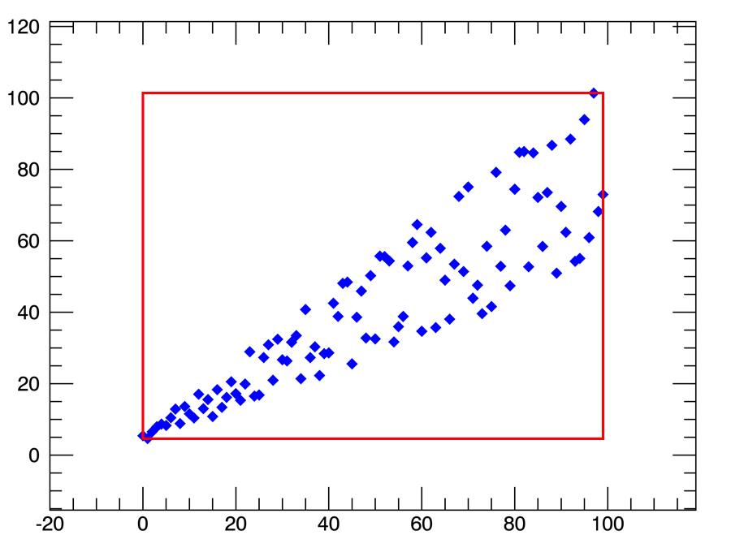

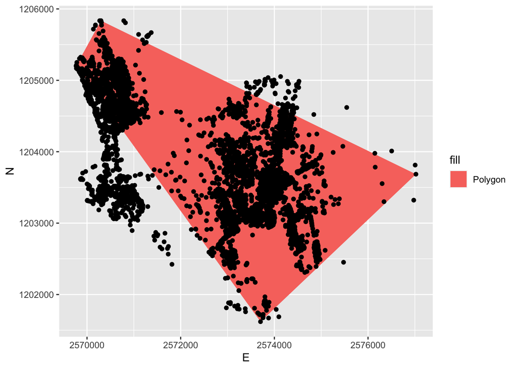

*Figure 2: Ueli’s (ID 1) location over the study period, and the resulting polygon created from the for extreme points.*

## Results

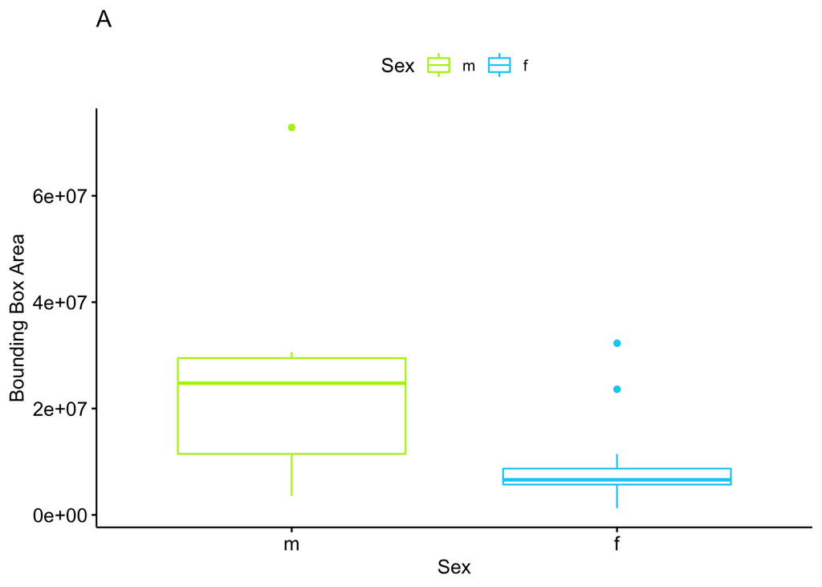

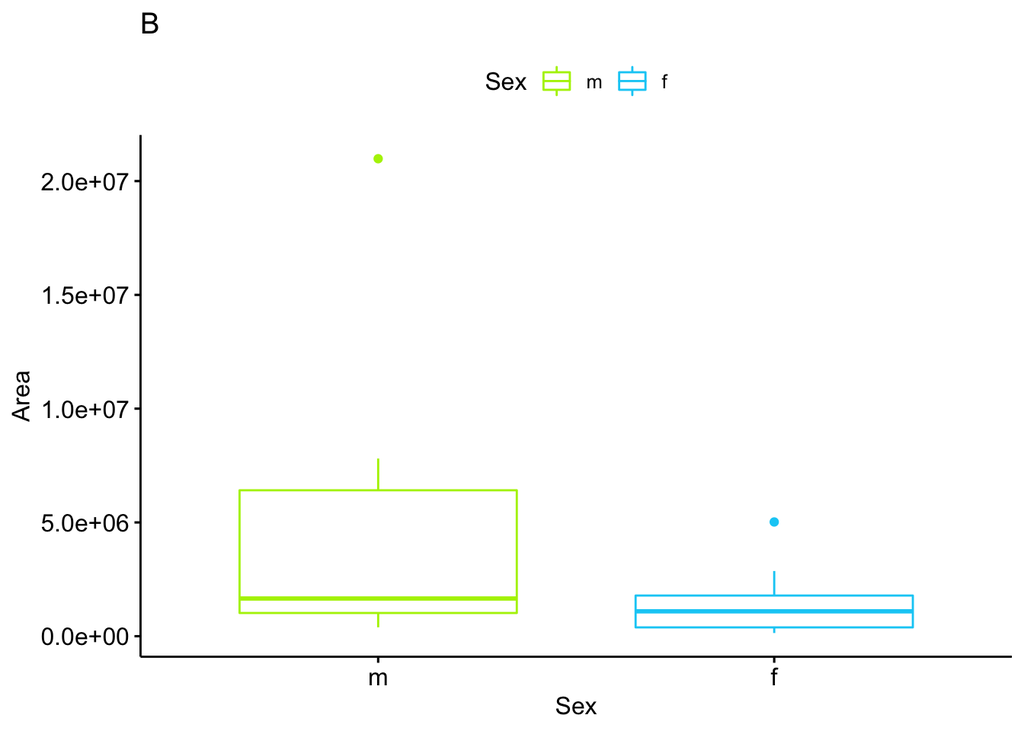

*Figure 3: Box plots of the resulting areas from the Bounding Box Method (A) and the Max-Min Polygon Method (B).*

```
## # A tibble: 2 × 4
##   Sex   count      mean        sd
##   <chr> <int>     <dbl>     <dbl>
## 1 f        13  9545601.  8770214.
## 2 m         6 27337037. 24728236.
```

```
## # A tibble: 2 × 4
##   Sex   count     mean       sd
##   <chr> <int>    <dbl>    <dbl>
## 1 f        13 1455357. 1375323.
## 2 m         6 5582496. 8019536.
```

[interactive chart not shown]

*Figure 4: Resulting Polygons for each pig overlaid on a map of Switzerland.* *Blue* *indicates male pigs,* *Green* *indicates female pigs.*

## Discussion

The first possible explanation is the existence of physical constraints on these pigs. When these polygons are laid over a land use map (fig 4 and 5), there is a potential pattern showing that these pigs are staying in areas with tree covers. Looking further at these maps, there is a barrier of cropland and built-up land cover separating the main tree cover areas and neighboring tree covers. The possibility of physical constraints is further strengthened by the reported territory sizes of the wild boars: females averaging 750ha, while males average 1,500ha (Kueling and Leus, 2019). These values are much higher than the averages produced in the min-max polygon method, a method that more closely aligns to the true area covered.

[figure not shown]

Figure 5: Largest Polygon (pig 48) overlaying map of land use from Esri and the ESA.

[figure not shown]

Figure 6: Smallest Polygon (pig 83) over land use map from Esri and the ESA.

A second explanation could be that neither of these methods are suitable for estimating movement and home ranges. It should be noted that the min-max polygon was a method invented by the author and not authenticated by any other researchers. However, the bounding-box method is an established method, and though not an estimation of actual home ranges, it does produce consistent results for comparison.

A third explanation, and possibly the most likely, is the sample size. With only 6 males and 13 females, there are not enough data points to draw any strong conclusions. Looking back on the box plots, there are several outliers in both sexes. To better analyze the effectiveness of these methods, more pigs need to be added to the data set. It’s possible that pig 83 was the female responsible for caring for the the herds young, and thus didn’t move much. Pig 48 could have been swept up the lake and had to walk back, dramatically expanding its range, or the collar could have fallen off and been carried away. When more data points are added, weird occurrences like pigs 83 and 48 will have less influence on the overall patterns. Including more pigs from other areas around Europe will also remove the possible effect physical constraints could have had on the pigs. Pigs in Munich aren’t be affected by Lac de Neuchatel, just as pigs in Bern aren’t affected by the Isar.

## References

Wickline, K. (2014). Sus scrofa. Retrieved June 3, 2022, from https://animaldiversity.org/site/accounts/information/Sus_scrofa.html#880B0B11-4354-11E3-8D47-002500F14F28

Keuling, O., & Leus, K. (2019). Sus scrofa (Wild Boar). Retrieved June 30, 2022, from https://www.iucnredlist.org/species/41775/44141833#habitat-ecology